# Part II - Ford GoBike System Data Exploration

## by Fenny Tsai

## Investigation Overview

> - What are the riders gender, age, and usertype distribution?
> - What are the rush hour of the rides in a day and a week.
> - What are the features affecting the trip duration?

## Dataset Overview

> This data set includes information about individual rides made in a bike-sharing system covering the greater San Francisco Bay area.

## Distribution of Rider Gender

Male rides the bike more than gender Female and Other.

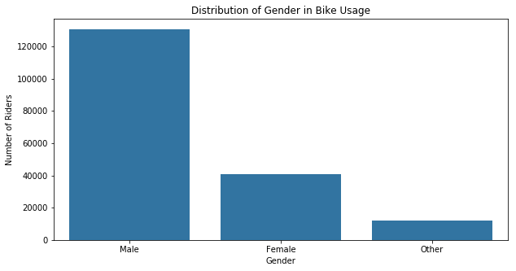

## Distribution of rider age

The bike user's age range from 20 to 39 uses the bike most.

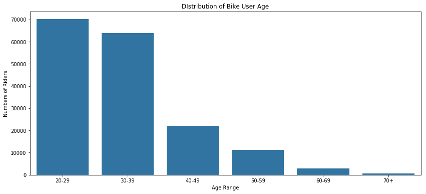

## Distribution of rider user type

Subscriber has much more usage on the bike.

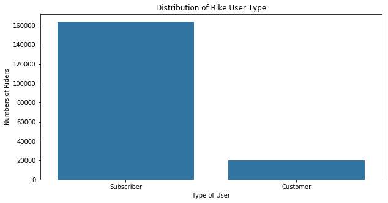

## Distribution of Ride Usage in a Day

Most of the riders uses the bike in the evening, then morning.

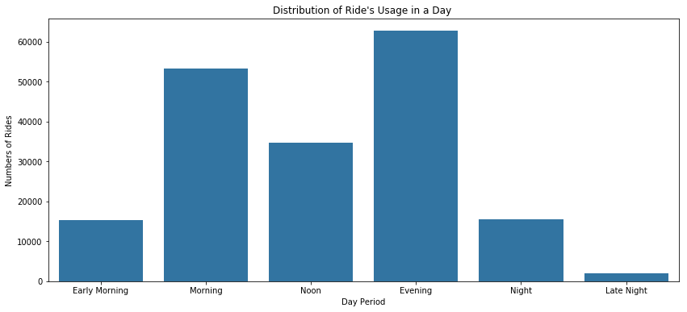

## Distribution of Ride Usage of a Week

The bikes are be mostly used in week days than weekend.

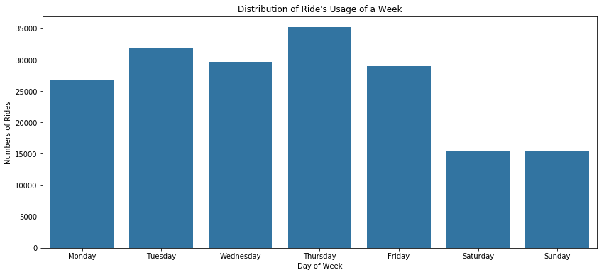

## The relationship between using duration and day of week by user type

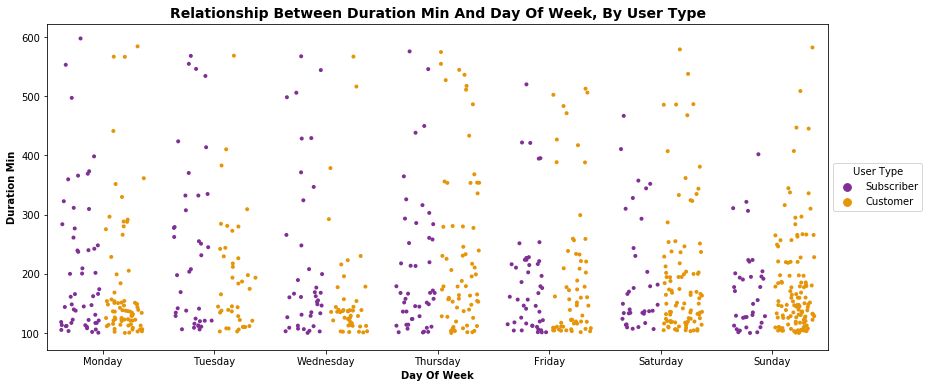

## The relationship between using duration and age range by user type

In age range 30-39 and below, customers has more users than subscribers, and customers also use the bike in a longer period in this age range. On the other hand, age range above 40, there are more subscribers than customers and subscribers use the bike in a longer period.

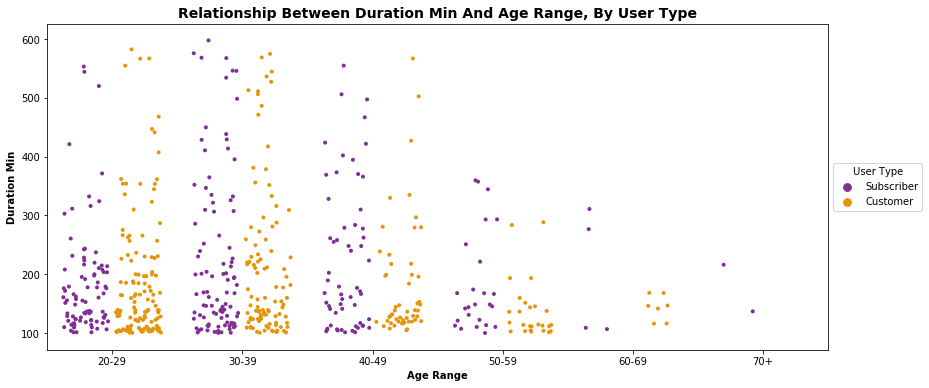

## The relationship between using duration and day period timing in a day by user type

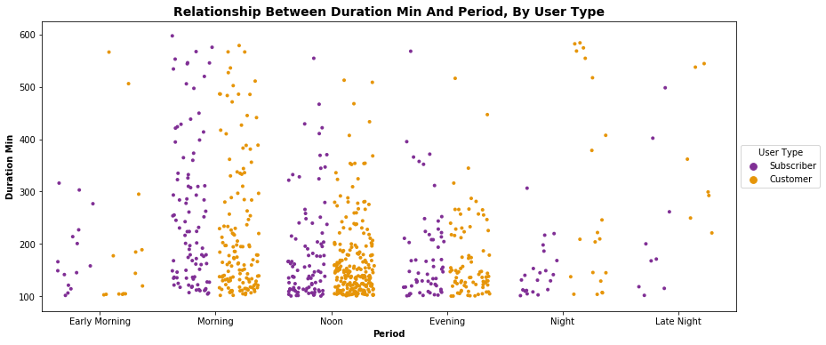

## The relationship between using duration and day of week by age range

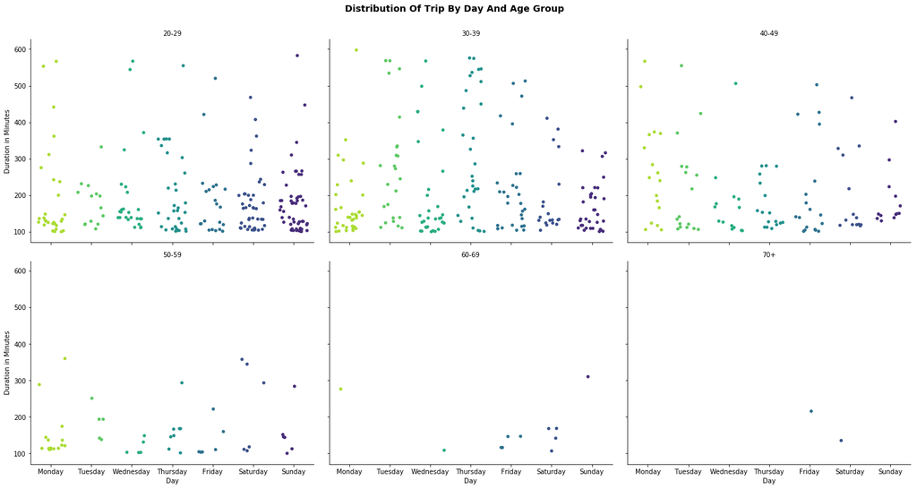